# hw4

**Q1**

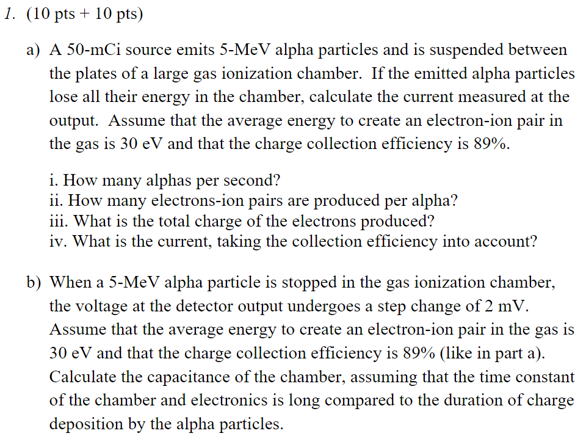

Ooh detector physics!  
(a)

```
i. How many alphas
```

$$ 1 \text{Ci} = 3.7\times 10^{10} \\ 50 \text{mCi} = 50\times 3.7 \times 10^{7} \alpha/s $$ Comes out to $1.85\times10^9$ alpha particles per second

```
ii. How many electrons-ion pairs are produced per alpha?
```

Bringing a $5$-MeV particle to stopped (ignoring 3.7GeV rest energy for $\alpha$-particles) by creating $30$-eV particles would create $$ 5\times 10^6 /30 = 1.67 \times 10^5 e/\alpha \\ (1.67 \times 10^5)(1.85\times10^9) = 3.09 \times 10^{14} e/s $$ Which also checks off iii.

```
iv. What is the current, taking the collection efficiency into account?
```

Current is charge/sec (no velocity?), so multiplying by efficiency yields $$ 3.09 \times 10^{14} \times.89 = 2.75\times 10^{14} e/s \\ = 2.75 \times 1.602 \times 10^{-5} C/s = 4.406 \times 10^{-5} A $$

(b) Just use $Q=CV$, assume all $Q$ from one particle arrives simultaneously.

Charge per $\alpha$: $1.67\times 10^5 e/\alpha$

$$ \frac{1.67\times 10^5 e}{\alpha}\frac{1.602\times 10^{-19}C}{e} = 2.68\times 10^{-14} C/\alpha \\ C = \frac{Q}{V} = \frac{2.68\times 10^{-14}\times .89}{2\times 10^{-3}} = 1.19\times 10^{-11} = 11.9 pF $$

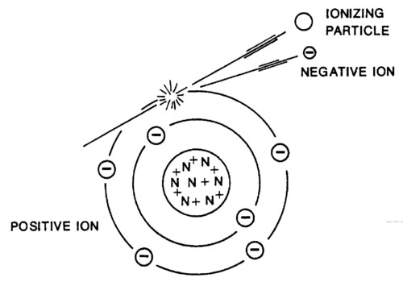

**Q2**

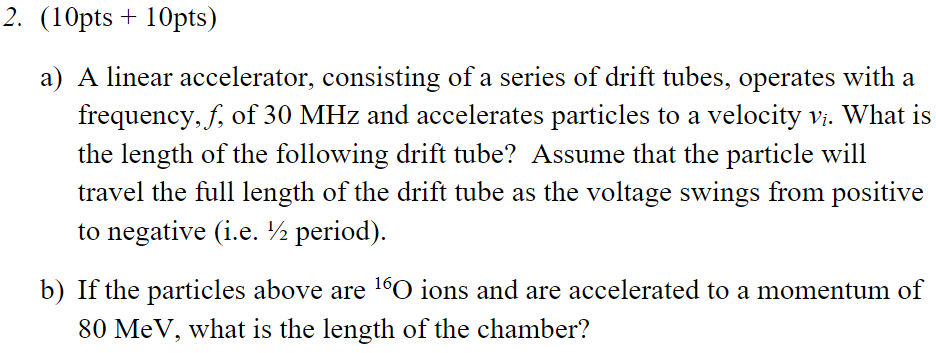

(a) The period is

$$ \frac{1}{30\times 10^6} = 3.3\times 10^{-8}s = 33ns \\ \Delta x = vt \\ \Delta x = v_i(3.3\times 10^{-8}s/2) = v_i \times 1.65\times 10^{-8} $$ So if $v_i = 1 m/s$ the tube is only $16.4nm$ long.

(b) What is the velocity of $^{16}O$ at $80\text{ MeV}$?

Low compared to GeV rest energy, nonrelativistic. Start with $c=1$

$$ v = \frac{p}{m} = \frac{80 \text{MeV}}{16u*931.5\text{MeV/u}} = \frac{80}{14927.7} = 0.00537 \\ c = 3e8 \rightarrow v = 1.6\times 10^6 m/s \\ \Delta x = 1.6\times 10^6\times 1.65\times 10^{-8} = 2.66\text{cm} $$

Helps explain how fast particles are moving through 644Mhz FRIB cavities

**Q3**

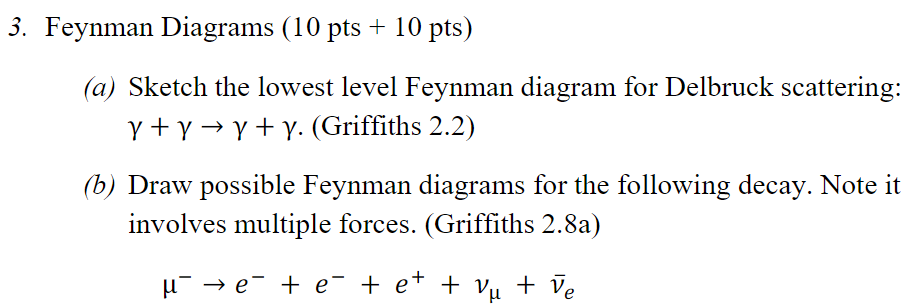

(a) if only they were gluons instead of photons

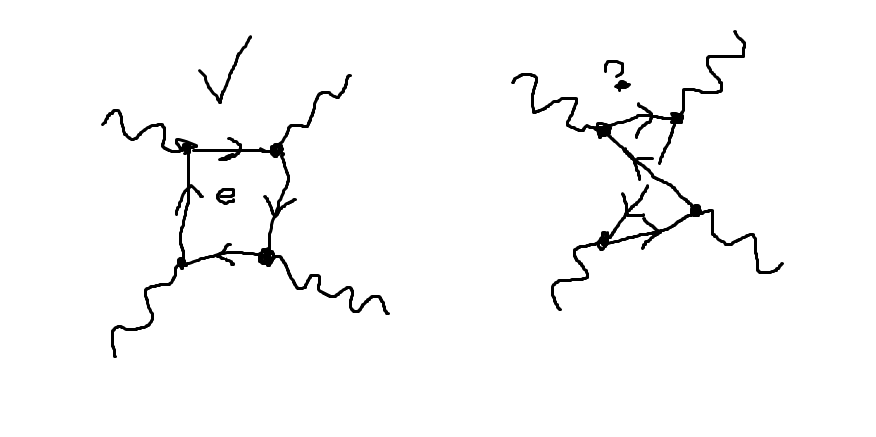

The image on the left is what wikipedia reports to be correct, but is the one on the right also lowest-level?

(b) One heavy muon.

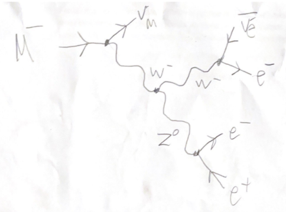

There are infinitely many highly-unlikely higher-order diagrams. This one will do for me.

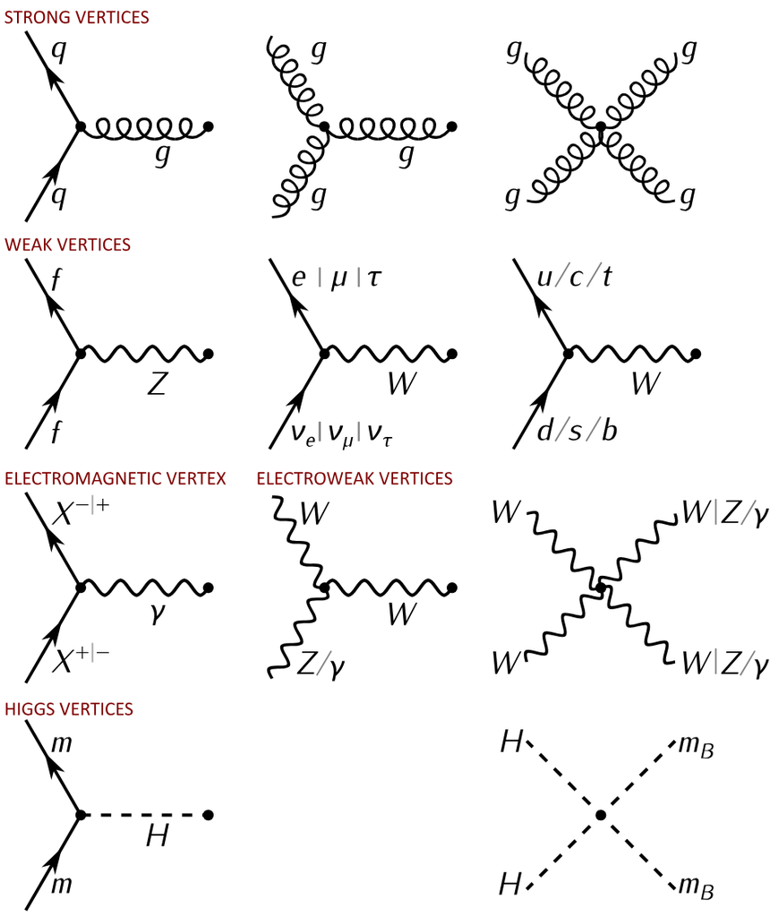

**Q4**

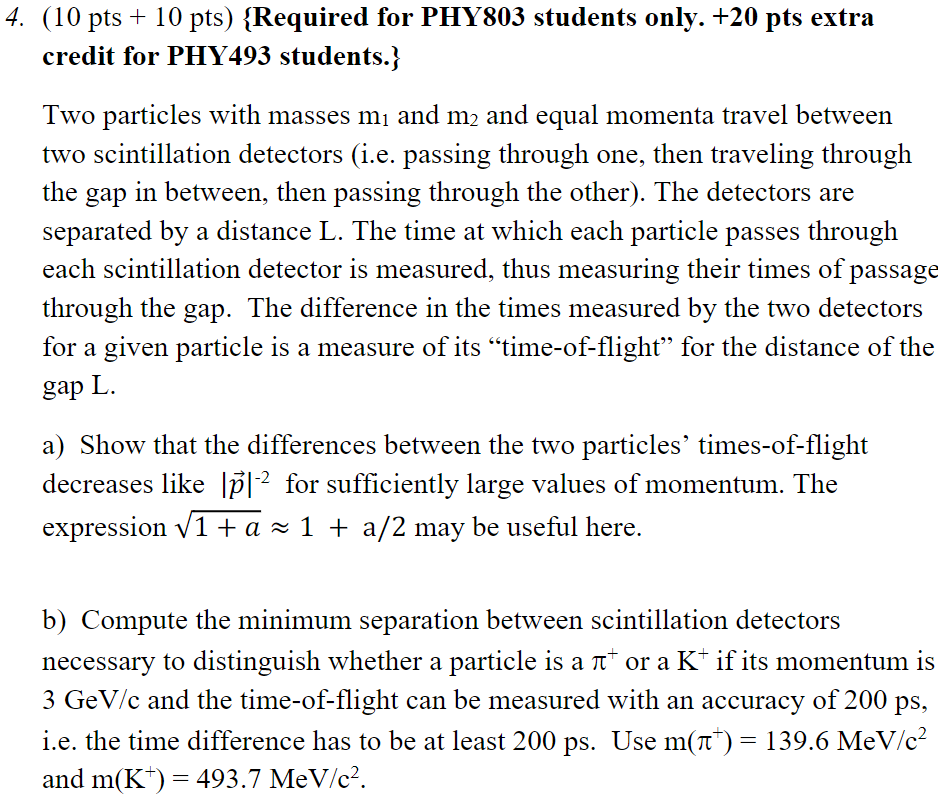

(a) The hint makes me think we're using $E = \sqrt{p^2+m^2}$

$$ E \approx p\left(1+\frac{m^2}{2p^2}\right) \\ $$ Using $v= \frac{p}{E}$ and $c=1$, we need to get a $1/p^2$ term. According to the internet we can use $\frac{1}{1-x} \approx 1+x$ for small enough $x$ $$ v = 1 - \frac{m^2}{2p^2} \\ \frac{1}{v} = \frac{1}{1-\frac{m^2}{2p^2}} \approx 1 + \frac{m^2}{2p^2} \\ t_1 - t_2 = L\left(\frac{m_1^2}{2p^2} - \frac{m_2^2}{2p^2}\right) \\ \Delta t= \frac{L}{2} \left(\frac{|m_1^2-m_2^2|}{p^2} \right) $$

Easy!

(b) Plug in

$$ L = \frac{\Delta t}{2} \frac{p^2}{|m_1^2 - m_2^2|} \\ = \frac{200\times 10^{-12}}{2} \frac{3000 ^2}{|139.6^2 - 493.7^2|} \\ = 4\times 10^{-9}m \\ = 4 nm $$

```python
200e-12/2*3000**2/(abs(139.6**2-493.7**2))
```

```
4.01335054436418e-09
```

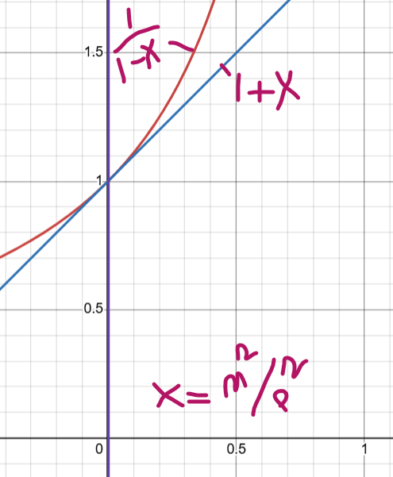

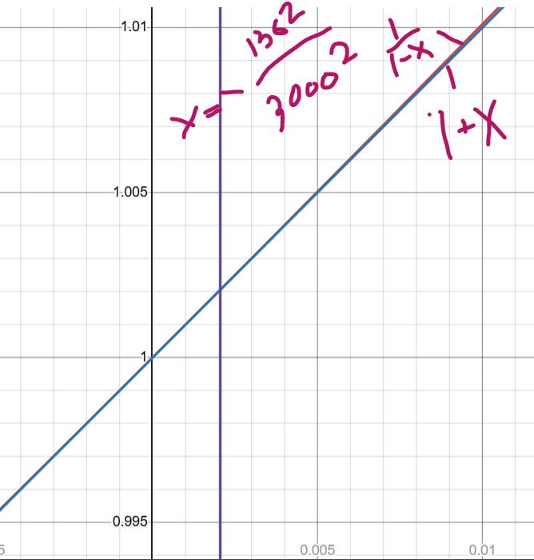

The approximation $\frac{1}{1-x} \approx 1+x$ is valid for high enough momenta. For $m = .1 |p|$, the error is less than $10^{-4}$. Also, it is $x=\frac{m^2}{2p^2}$ not $x=\frac{m^2}{p^2}$, which makes $x$ smaller and thus more accurate